# PeñaMontenegro_et_al_2020_R_b-diversity

**Supporting code used for the paper:**

**Metatranscriptomic analysis reveals responses of deepsea microbial communities to oil and dispersant exposure**

*Tito D. Peña-Montenegro<sup>1,2</sup>, Sara Kleindienst<sup>3</sup>, Andrew E. Allen<sup>4,5</sup>, A. Murat Eren<sup>6,7</sup>, Juan David Sánchez-Calderón<sup>8</sup>, Jonathan Arnold<sup>2,9</sup>, Samantha B. Joye<sup>1,</sup>*</sup>*

```r
#Following method at http://kembellab.ca/r-workshop/biodivR/SK_Biodiversity_R.html
library(picante)
library(reshape2)
```

```r
setwd("/Users/tito-admin/Tito/JOYELABACKUP/SK_BACKUP/p22_Jupyter/Data/b-diversity/")
```

```r
comm_longfmt <- read.csv("/Users/tito-admin/Tito/JOYELABACKUP/SK_BACKUP/p22_Jupyter/Data/Fig1_data_simple_absolute_melt.csv", header = TRUE, row.names = 1)
#Transforming into compact(wide) format
comm = dcast(comm_longfmt, sample_names~variable)
comm$sample_names <- c('BC_0', 'BC_1', 'BC_2', 'BC_3', 'BC_4', 'D_0', 'D_1', 'D_2', 'D_3', 'D_4', 'WAF_0', 'WAF_1A', 'WAF_1B', 'WAF_2', 'WAF_3', 'WAF_4A', 'WAF_4B', 'CEWAF_0', 'CEWAF_1A', 'CEWAF_1B', 'CEWAF_2', 'CEWAF_3' ,'CEWAF_4A' ,'CEWAF_4B' , 'CEWAF+N_0' ,'CEWAF+N_1' , 'CEWAF+N_4')

#setting row names
comm2 <- comm[,-1]
rownames(comm2) <- comm[,1]
comm_v0 = comm
comm = comm2
```

```r
comm['A'] <- comm$Bacteroidetes + comm$Flavobacteriaceae
comm$Bacteroidetes <- NULL
comm$Flavobacteriaceae <- NULL
colnames(comm)[colnames(comm)=="A"] <- "Bacteroidetes"
comm['A'] <- comm$Pseudomonas + comm$Gammaproteobacteria
comm$Pseudomonas <- NULL
comm$Gammaproteobacteria <- NULL
colnames(comm)[colnames(comm)=="A"] <- "Gammaproteobacteria"
```

```r
head(rownames(comm))
```

1. 'BC_0'

2. 'BC_1'

3. 'BC_2'

4. 'BC_3'

5. 'BC_4'

6. 'D_0'

```r
head(colnames(comm))
```

1. 'Alcanivorax'

2. 'Alphaproteobacteria'

3. 'Alteromonadales'

4. 'Archaea'

5. 'Bacteria'

6. 'Bermanella'

```r
comm[1:5,1:5]
```

A data.frame: 5 × 5

|  | Alcanivorax <int> | Alphaproteobacteria <int> | Alteromonadales <int> | Archaea <int> | Bacteria <int> |
| --- | --- | --- | --- | --- | --- |
| BC_0 | 7798 | 13340 | 21282 | 5913 | 16557 |
| BC_1 | 3172 | 9134 | 11015 | 3471 | 10222 |
| BC_2 | 2645 | 10407 | 15469 | 4818 | 13194 |
| BC_3 | 1333 | 5680 | 8240 | 1636 | 7248 |
| BC_4 | 849 | 3919 | 4792 | 1179 | 6460 |

```r
#check total abundance in each sample
head(apply(comm, 1, sum))
```

**BC_0**

267276

**BC_1**

160747

**BC_2**

216421

**BC_3**

164783

**BC_4**

170340

**D_0**

195117

```r
#Turn percent cover to relative abundace by diving each value by sample total abundance
comm <-decostand(comm, method="total")
#check total abundacne in each sample
head(apply(comm, 1, sum))
```

**BC_0**

1

**BC_1**

1

**BC_2**

1

**BC_3**

1

**BC_4**

1

**D_0**

1

```r
#look at the transformed data
comm[1:5,1:5]
```

A data.frame: 5 × 5

|  | Alcanivorax <dbl> | Alphaproteobacteria <dbl> | Alteromonadales <dbl> | Archaea <dbl> | Bacteria <dbl> |
| --- | --- | --- | --- | --- | --- |
| BC_0 | 0.029175833 | 0.04991095 | 0.07962556 | 0.022123198 | 0.06194720 |
| BC_1 | 0.019732872 | 0.05682221 | 0.06852383 | 0.021592938 | 0.06359061 |
| BC_2 | 0.012221550 | 0.04808683 | 0.07147643 | 0.022262165 | 0.06096451 |
| BC_3 | 0.008089427 | 0.03446958 | 0.05000516 | 0.009928209 | 0.04398512 |
| BC_4 | 0.004984149 | 0.02300693 | 0.02813197 | 0.006921451 | 0.03792415 |

## Metadata

```r
#replace filename with file.choose() to open interactive window
metadata <- read.csv('metadata_picante.csv', header=TRUE, row.names = 1)
#take a peek at the data
head(metadata)
```

A data.frame: 6 × 5

|  | Treatment <fct> | Dispersant <int> | Oil <int> | Nutrients <int> | Time <int> |
| --- | --- | --- | --- | --- | --- |
| BC_0 | BC | 0 | 0 | 0 | 0 |
| BC_1 | BC | 0 | 0 | 0 | 7 |
| BC_2 | BC | 0 | 0 | 0 | 17 |
| BC_3 | BC | 0 | 0 | 0 | 28 |
| BC_4 | BC | 0 | 0 | 0 | 42 |
| D_0 | D | 1 | 0 | 0 | 0 |

## Phylogeny

```r
phy <- read.tree('v3_1000_iterations.newick')
class(phy)
```

'phylo'

```r
phy
```

```
Phylogenetic tree with 27 tips and 26 internal nodes.

Tip labels:
	Eukaryota, Chromista, Neoparamoeba, Archaea, Bacteroidetes, Flavobacteriales, ...

Rooted; includes branch lengths.
```

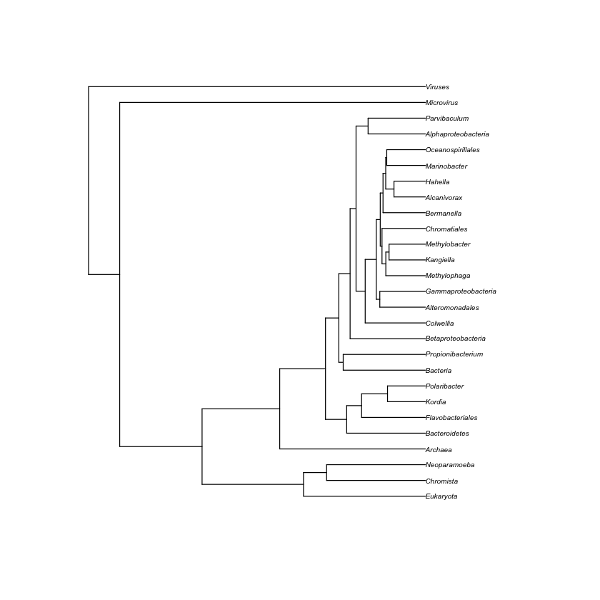

```r
plot(phy, cex=0.5)
```

## Cleaning and matching data sets

```r
#check for mismatches/missing species
combined <- match.phylo.comm(phy, comm)
#the resulting object is a list with $phy and $data elements.
#Replace our original data with the sorted/matched data
phy <- combined$phy
comm <- combined$comm
```

```r
#we should check whether our community data and metadata are in the same order
all.equal(rownames(comm), rownames(metadata))
```

TRUE

```r
#if sorting is needed
#metadata <- metadata[rownames(comm),]
```

```r
## check later this if there is time
#chisq.test(specnumber(comm)~metadata$Treatment)
```

## Multivariate community analysis

How does the composition of microbial communities vary across different samples? How are Treatments and Time related to the microbial community composition?

We can use multivariate ordination methods to explore community structure in more detail. These methods are available in the vegan package, which also includes excellent documentation and tutorials for these methods. The book “Numerical Ecology in R” by Borcard et al. gives a great overview of multivariate analysis methods.

### Hierarchical clustering

We can cluster together plots based on their overall community composition. We will calculate Bray-Curtis dissimilarity among all the samples, an abundance-weighted measure of how similar two communities are in terms of their species composition. We will then cluster together communities that are similar using an agglomerative hierarchical clustering algorithm.

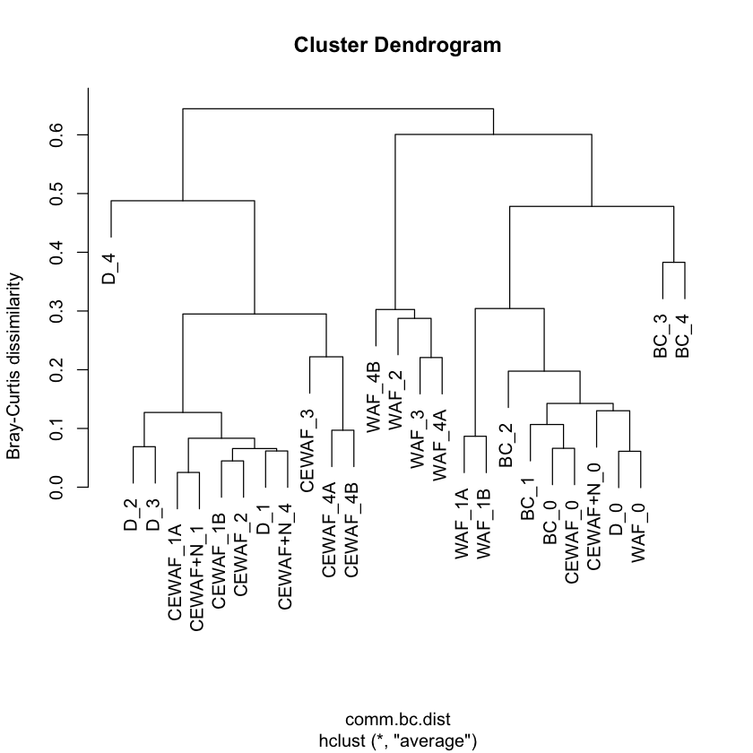

```r
# calculate Bray-Curtis distance among samples
comm.bc.dist <- vegdist(comm, method = "bray")
# cluster communities using average-linkage algorithm
comm.bc.clust <- hclust(comm.bc.dist, method = "average")
# plot cluster diagram
plot(comm.bc.clust, ylab = "Bray-Curtis dissimilarity")
```

```r
svg(filename="FigS4G_Bray-Curtis_dissimilarity.svg")
plot(comm.bc.clust, ylab = "Bray-Curtis dissimilarity")
dev.off()
```

**pdf:** 2

# Ordination

There are numerous ordination methods available in R. For now, let's use non-metric multidimensional scaling to visualize the multivariate structure of these communities.

```r
# The metaMDS function automatically transforms data and checks solution
# robustness
comm.bc.mds <- metaMDS(comm, dist = "bray")
```

```
*** Solution reached
```

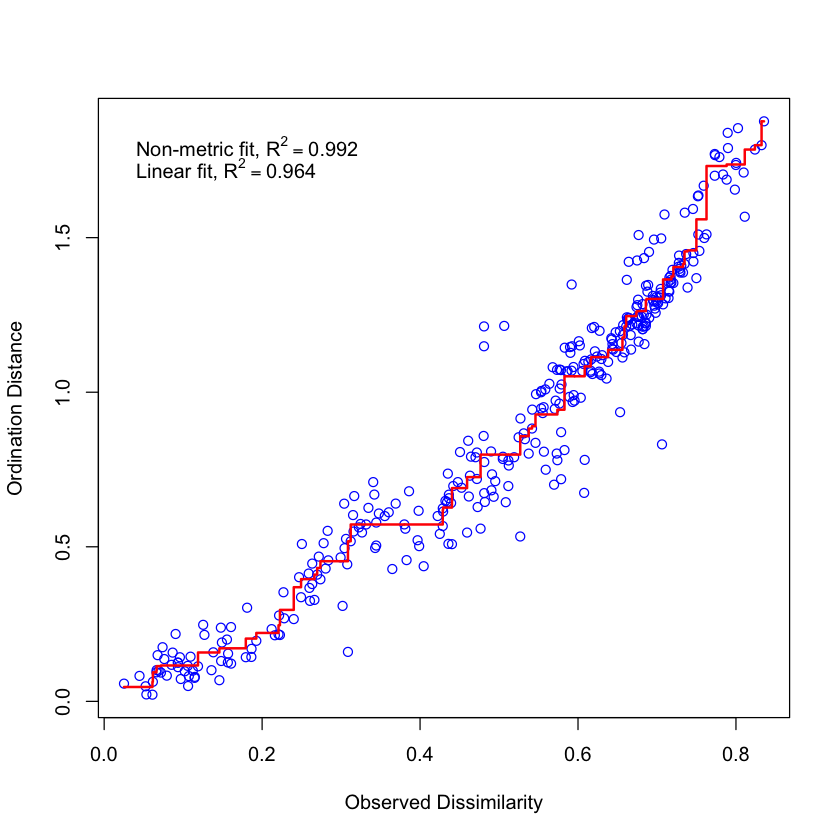

```r
# Assess goodness of ordination fit (stress plot)
stressplot(comm.bc.mds)
```

We can plot the ordination results in a variety of different ways.

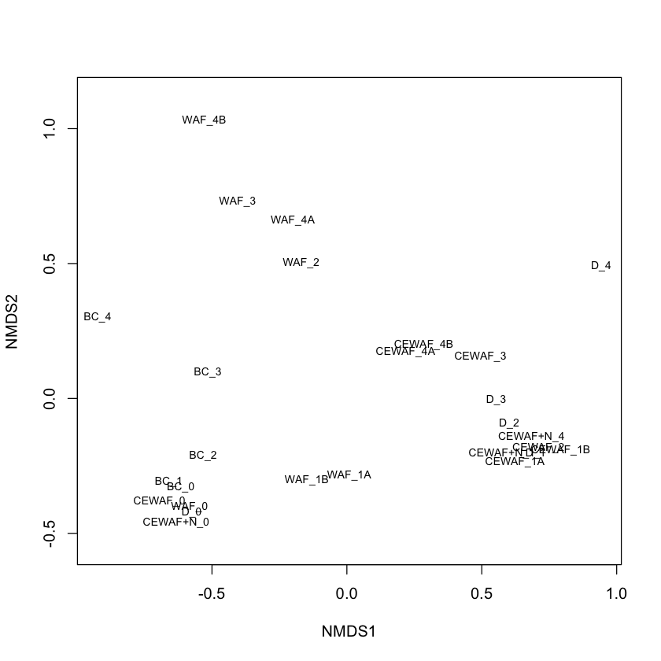

```r
# plot site scores as text
ordiplot(comm.bc.mds, display = "sites", type = "text")
```

```r
p1 = comm.bc.mds$points
p1 = as.data.frame(p1)
p1['Feature'] <- c('sample','sample','sample','sample','sample','sample','sample','sample','sample','sample','sample','sample','sample','sample','sample','sample','sample','sample','sample','sample','sample','sample','sample','sample','sample','sample','sample')
p2 = comm.bc.mds$species
p2 = as.data.frame(p2)
p2['Feature'] <- c('species','species','species','species','species','species','species','species','species','species','species','species','species','species','species','species','species','species','species','species','species','species','species','species','species','species','species')
nmds_data <- rbind(p1,p2)
write.csv(nmds_data, file = "Fig3_nmds_data_for_plot.csv")
```

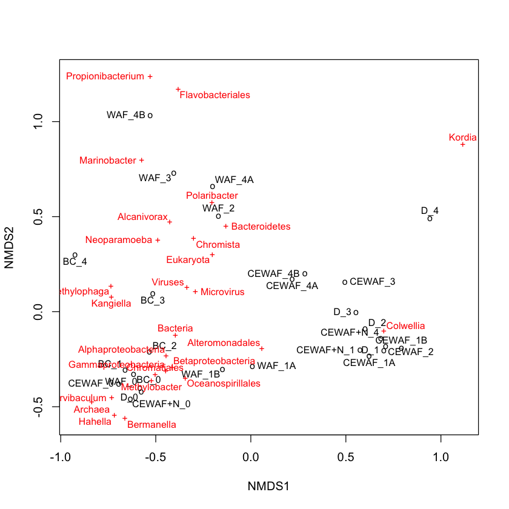

```r
# automated plotting of results - tries to eliminate overlapping labels
ordipointlabel(comm.bc.mds)
```

```
Family: gaussian
Link function: identity

Formula:
y ~ s(x1, x2, k = 10, bs = "tp", fx = FALSE)

Estimated degrees of freedom:
8.91  total = 9.91

REML score: -55.32544
```

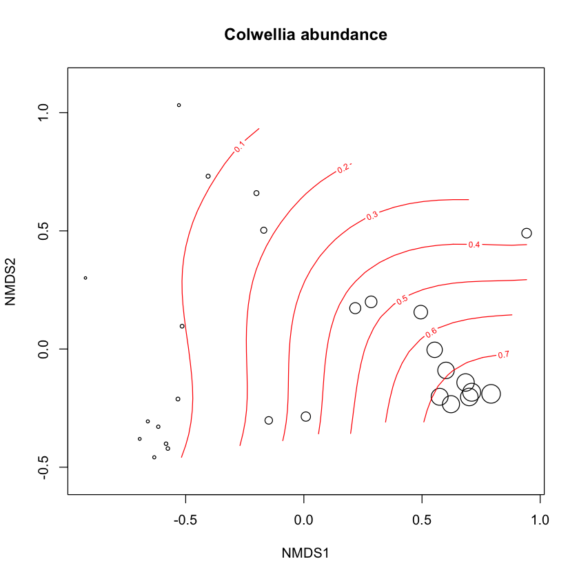

```r
# plot Colwellia abundance. cex increases the size of bubbles.
ordisurf(comm.bc.mds, comm[, "Colwellia"], bubble = TRUE, main = "Colwellia abundance",
    cex = 3)
```

```
Family: gaussian
Link function: identity

Formula:
y ~ s(x1, x2, k = 10, bs = "tp", fx = FALSE)

Estimated degrees of freedom:
7.57  total = 8.57

REML score: -32.06745
```

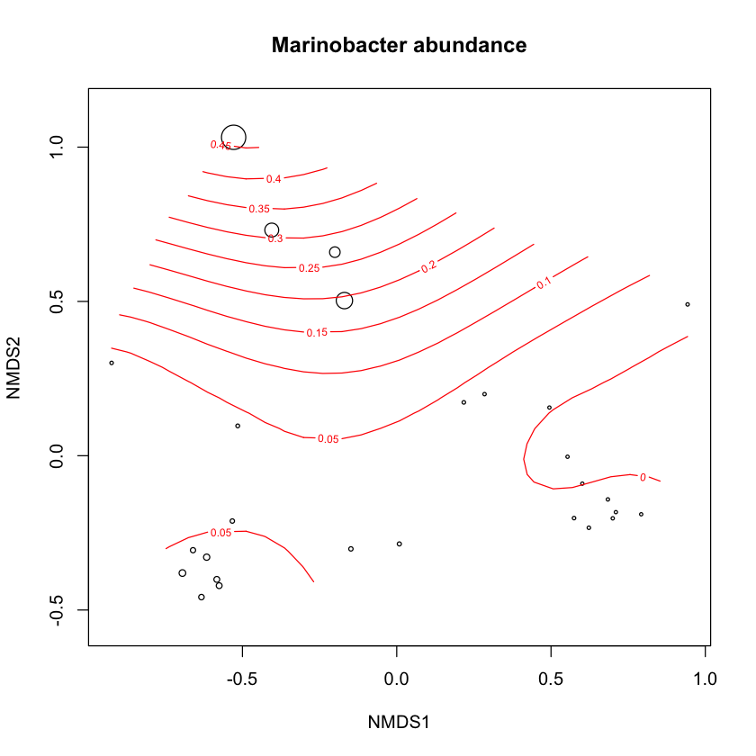

```r
# plot Colwellia abundance. cex increases the size of bubbles.
ordisurf(comm.bc.mds, comm[, "Marinobacter"], bubble = TRUE, main = "Marinobacter abundance",
    cex = 3)
```

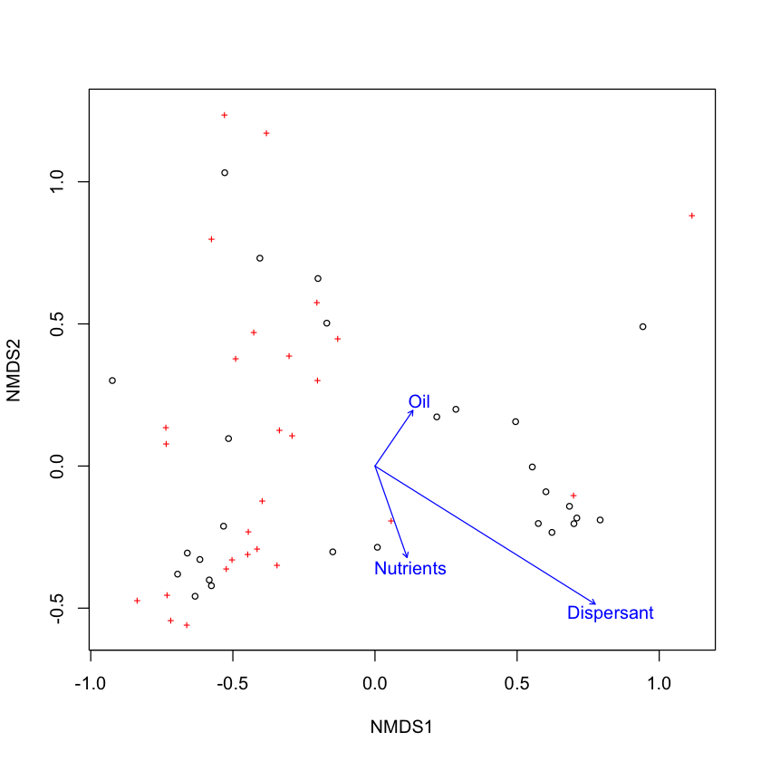

```r
ordiplot(comm.bc.mds)
# calculate and plot environmental variable correlations with the axes use
# the subset of metadata that are environmental data
plot(envfit(comm.bc.mds, metadata[, 2:4]))
```

# Ordination II

Doing the same thing but with PCA

```r
# The metaMDS function automatically transforms data and checks solution
# robustness
#comm.bc.pca <- metaMDS(comm, dist = "bray")
```

```r
# First step is to calculate a distance matrix.
# Here we use Bray-Curtis distance metric
comm.bc.vegdist <- vegdist(comm,  method = "bray")
```

```r
# PCoA is not included in vegan.
# We will use the ape package instead
library(ape)
PCOA <- pcoa(comm.bc.vegdist)
```

```r
# plot the eigenvalues and interpret
#barplot(PCOA$values$Relative_eig[1:10])
PCOA$values$Relative_eig[1:10]
```

1. 0.553453314549708

2. 0.237784428777649

3. 0.0993224339555511

4. 0.0580317706709635

5. 0.0234286351306846

6. 0.0202983330356126

7. 0.0137114889067147

8. 0.00917993330779548

9. 0.00646329818539521

10. 0.00551553490197085

```r
Y = comm
x = PCOA
plot.axes = c(1, 2)
pr.coo <- x$vectors
n <- nrow(Y)
points.stand <- scale(pr.coo[, plot.axes])
S <- cov(Y, points.stand)
U <- S %*% diag((x$values$Eigenvalues[plot.axes]/(n - 1))^(-0.5))
#We need is points.stand and U to export to be plotted in altair
```

```r
# Write CSV in R
write.csv(points.stand, file = "Fig3_pca_samples.csv")
write.csv(U, file = "Fig3_pca_species.csv")
```

## $MPD$, $MNTD$, $SES_{MPD}$ and $SES_{MNTD}$

Another way of thinking about the phylogenetic relatedness of species in a community is to ask 'how closely related are the average pair of species or individuals in a community', and relate the patterns we observe to what we'd expect under various null models of evolution and community assembly. These types of questions are addressed by the measures of community phylogenetic structure such as MPD, MNTD, NRI and NTI described by Webb et al. and implemented in Phylocom.

If the community data represent abundance measures, the abundance data can be taken into account. Doing so changes the interpretation of these metrics from the average distance among two randomly chosen species from a community, to the average distance among two randomly chosen individuals in a community.

Measures of 'standardized effect size' of phylogenetic community structure can be calculated for MPD and MNTD by compared observed phylogenetic relatedness to the pattern expected under some null model of phylogeny or community randomization. Standardized effect sizes describe the difference between average phylogenetic distances in the observed communities versus null communities generated with some randomization method, standardized by the standard deviation of phylogenetic distances in the null data:

$SES_{metric} = \frac{ Metric_{observed} - mean(Metric_{null}) }{sd(Metric_{null})}$

```r
# convert phylogenety to a distance matrix
phy.dist <- cophenetic(phy)
```

```r
# calculate ses.mpd
comm.sesmpd <- ses.mpd(comm, phy.dist, null.model = "taxa.labels", abundance.weighted = TRUE, runs = 999)
head(comm.sesmpd)
#If there is an error run
#vec1 = colnames(comm)
#vec2 = colnames(phy.dist)
#setdiff(vec2,vec1)
#setdiff(vec1,vec2)
```

A data.frame: 6 × 8

|  | ntaxa <int> | mpd.obs <dbl> | mpd.rand.mean <dbl> | mpd.rand.sd <dbl> | mpd.obs.rank <dbl> | mpd.obs.z <dbl> | mpd.obs.p <dbl> | runs <dbl> |
| --- | --- | --- | --- | --- | --- | --- | --- | --- |
| BC_0 | 27 | 0.2704630 | 0.4261616 | 0.07993540 | 7 | -1.9478050 | 0.007 | 999 |
| BC_1 | 27 | 0.3046536 | 0.4251318 | 0.08146594 | 32 | -1.4788781 | 0.032 | 999 |
| BC_2 | 27 | 0.2967192 | 0.4294765 | 0.08053378 | 25 | -1.6484668 | 0.025 | 999 |
| BC_3 | 27 | 0.3604121 | 0.4288612 | 0.08088532 | 222 | -0.8462488 | 0.222 | 999 |
| BC_4 | 27 | 0.3865453 | 0.3983323 | 0.10492300 | 563 | -0.1123392 | 0.563 | 999 |
| D_0 | 26 | 0.2701752 | 0.4175235 | 0.08934273 | 21 | -1.6492471 | 0.021 | 999 |

```r
# calculate ses.mntd
comm.sesmntd <- ses.mntd(comm, phy.dist, null.model = "taxa.labels", abundance.weighted = TRUE,
    runs = 999)
head(comm.sesmntd)
```

A data.frame: 6 × 8

|  | ntaxa <int> | mntd.obs <dbl> | mntd.rand.mean <dbl> | mntd.rand.sd <dbl> | mntd.obs.rank <dbl> | mntd.obs.z <dbl> | mntd.obs.p <dbl> | runs <dbl> |
| --- | --- | --- | --- | --- | --- | --- | --- | --- |
| BC_0 | 27 | 0.2036847 | 0.2638289 | 0.05665282 | 97 | -1.0616278 | 0.097 | 999 |
| BC_1 | 27 | 0.2262502 | 0.2639562 | 0.05809908 | 247 | -0.6489951 | 0.247 | 999 |
| BC_2 | 27 | 0.2168126 | 0.2642766 | 0.05407254 | 187 | -0.8777822 | 0.187 | 999 |
| BC_3 | 27 | 0.2260593 | 0.2640515 | 0.05504341 | 277 | -0.6902227 | 0.277 | 999 |
| BC_4 | 27 | 0.2339265 | 0.2642017 | 0.08968832 | 463 | -0.3375604 | 0.463 | 999 |
| D_0 | 26 | 0.2074234 | 0.2643301 | 0.06407793 | 165 | -0.8880855 | 0.165 | 999 |

The output includes the following columns:

- ntaxa - Number of taxa in community
- mpd.obs - Observed mpd in community
- mpd.rand.mean - Mean mpd in null communities
- mpd.rand.sd - Standard deviation of mpd in null communities
- mpd.obs.rank - Rank of observed mpd vs. null communities
- mpd.obs.z - Standardized effect size of mpd vs. null communities (equivalent to -NRI)
- mpd.obs.p - P-value (quantile) of observed mpd vs. null communities (= mpd.obs.rank / runs + 1)
- runs - Number of randomizations

Positive SES values (mpd.obs.z > 0) and high quantiles (mpd.obs.p > 0.95) indicate phylogenetic evenness, while negative SES values and low quantiles (mpd.obs.p < 0.05) indicate phylogenetic clustering, relative to the null model. MPD is generally thought to be more sensitive to tree-wide patterns of phylogenetic clustering and eveness, while MNTD is more sensitive to patterns of evenness and clustering closer to the tips of the phylogeny.

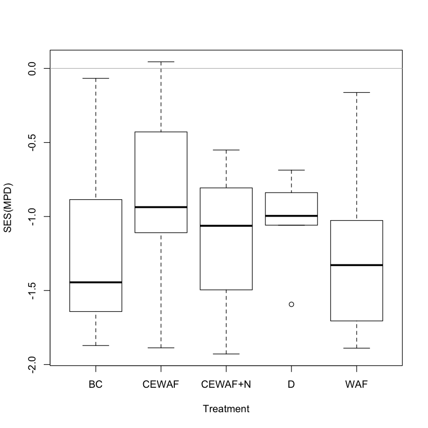

```r
# compare ses.mpd between habitats
plot(comm.sesmpd$mpd.obs.z ~ metadata$Treatment, xlab = "Treatment", ylab = "SES(MPD)")
abline(h = 0, col = "gray")
```

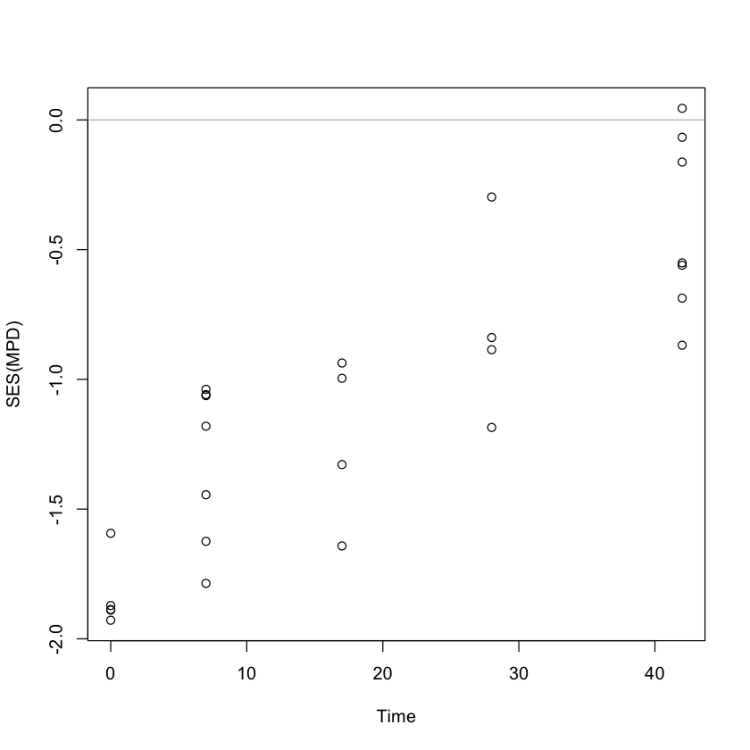

```r
# compare ses.mpd between habitats
plot(comm.sesmpd$mpd.obs.z ~ metadata$Time, xlab = "Time", ylab = "SES(MPD)")
abline(h = 0, col = "gray")
```

```r
#t.test(comm.sesmpd$mpd.obs.z ~ metadata$habitat)
# Compute the analysis of variance
res.aov <- aov(comm.sesmpd$mpd.obs.z ~ metadata$Treatment + metadata$Time, data = comm)
# Summary of the analysis
summary(res.aov)
```

```
                   Df Sum Sq Mean Sq F value   Pr(>F)
metadata$Treatment  4  0.743   0.186   2.313   0.0912 .
metadata$Time       1  6.436   6.436  80.174 1.29e-08 ***
Residuals          21  1.686   0.080
---
Signif. codes:  0 ‘***’ 0.001 ‘**’ 0.01 ‘*’ 0.05 ‘.’ 0.1 ‘ ’ 1
```

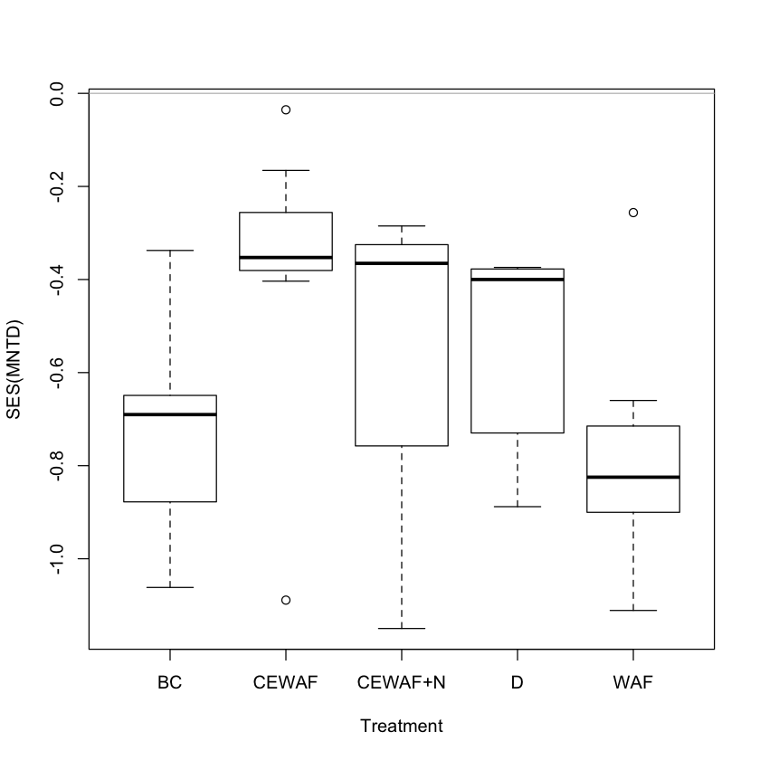

```r
# compare ses.mntd between habitats
plot(comm.sesmntd$mntd.obs.z ~ metadata$Treatment, xlab = "Treatment", ylab = "SES(MNTD)")
abline(h = 0, col = "gray")
```

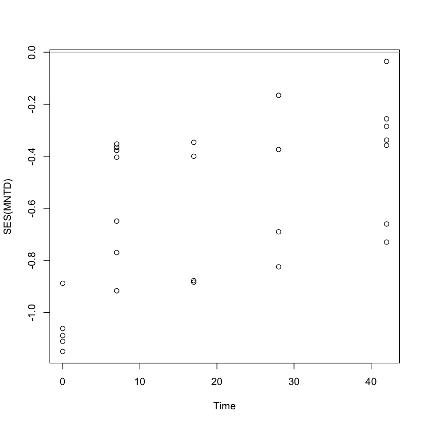

```r
# compare ses.mntd between habitats
plot(comm.sesmntd$mntd.obs.z ~ metadata$Time, xlab = "Time", ylab = "SES(MNTD)")
abline(h = 0, col = "gray")
```

```r
#t.test(comm.sesmntd$mntd.obs.z ~ metadata$habitat)
# Compute the analysis of variance
res.aov <- aov(comm.sesmntd$mntd.obs.z ~ metadata$Treatment + metadata$Time, data = comm)
# Summary of the analysis
summary(res.aov)
```

```
                   Df Sum Sq Mean Sq F value  Pr(>F)
metadata$Treatment  4 0.5994  0.1499   2.636 0.06293 .
metadata$Time       1 0.8851  0.8851  15.569 0.00074 ***
Residuals          21 1.1939  0.0569
---
Signif. codes:  0 ‘***’ 0.001 ‘**’ 0.01 ‘*’ 0.05 ‘.’ 0.1 ‘ ’ 1
```

```r
ordiplot(comm.bc.mds)
```

[output not shown]

# Phylogenetic and trait diversity

## Phylogenetic diversity

One of the earliest measures of phylogenetic relatedness in ecological communities was the phylogenetic diversity (PD) index proposed by Faith. Faith's PD is defined as the total branch length spanned by the tree including all species in a local community, optionally including the root node of the phylogeny. The pd function returns two values for each community, Faith's PD and species richness (SR).

```r
#TEST IF IT IS ROOTED
is.rooted(phy)
```

TRUE

```r
#rootedphy = root(phy, outgroup = 'Cenarchaeum',resolve.root = TRUE)
```

```r
# Calculate Faith's PD
comm.pd <- pd(comm, phy)
head(comm.pd)
```

A data.frame: 6 × 2

|  | PD <dbl> | SR <dbl> |
| --- | --- | --- |
| BC_0 | 4.402632 | 27 |
| BC_1 | 4.402632 | 27 |
| BC_2 | 4.402632 | 27 |
| BC_3 | 4.402632 | 27 |
| BC_4 | 4.402632 | 27 |
| D_0 | 4.241044 | 26 |

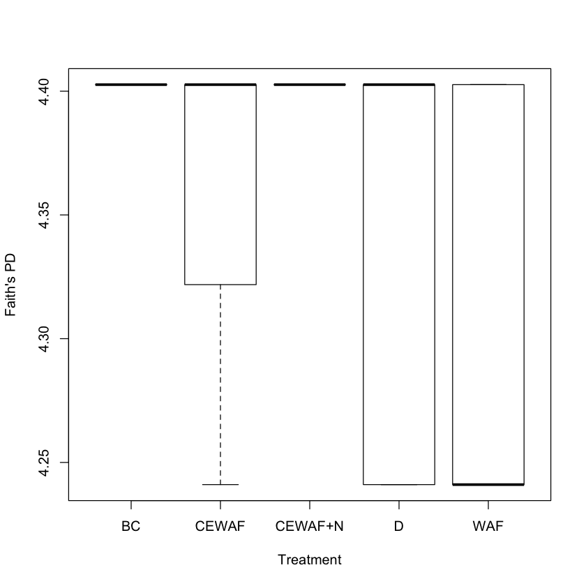

```r
# Plot Faith's PD by habitat
boxplot(comm.pd$PD ~ metadata$Treatment, xlab = "Treatment", ylab = "Faith's PD")
```

```r
# Test for PD differences among habitats
#t.test(comm.pd$PD ~ metadata$habitat)
# Compute the analysis of variance
res.aov <- aov(comm.pd$PD ~ metadata$Treatment + metadata$Time, data = comm)
# Summary of the analysis
summary(res.aov)
```

```
                   Df  Sum Sq Mean Sq F value  Pr(>F)
metadata$Treatment  4 0.03360 0.00840   2.308 0.09166 .
metadata$Time       1 0.03698 0.03698  10.161 0.00443 **
Residuals          21 0.07642 0.00364
---
Signif. codes:  0 ‘***’ 0.001 ‘**’ 0.01 ‘*’ 0.05 ‘.’ 0.1 ‘ ’ 1
```

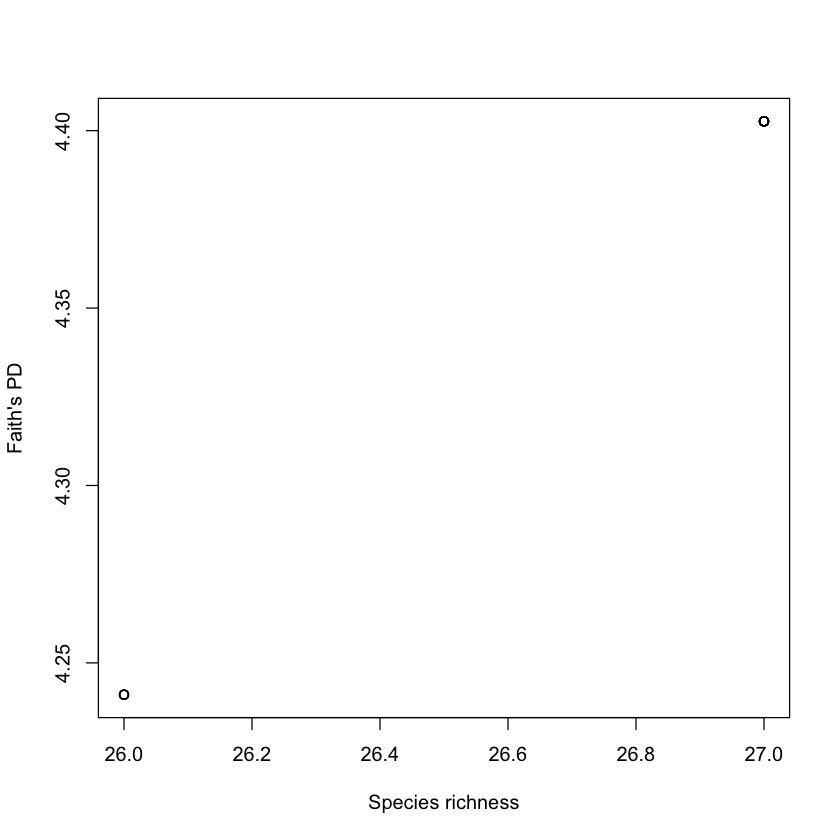

```r
# Compare PD and species richness
plot(comm.pd$PD ~ comm.pd$SR, xlab = "Species richness", ylab = "Faith's PD")
```

```r
# convert phylogenety to a distance matrix
phy.dist <- cophenetic(phy)
```

# Phylogenetic beta-diversity

We can measure patterns of phylogenetic relatedness among communities in a manner similar to the within-community phylogenetic diversity measures described above. The unifrac and phylosor functions measure the among-community equivalent of Faith's PD, the total unique/shared branch length between communities. The comdist and comdistnt functions measure the among-community equivalent of MPD and MNTD, the mean pairwise distance or mean nearest taxon distance between pairs of species drawn from two distinct communities.

Let's compare a few different ways of measuring dissimilarity among communities. We've already calculated the Bray-Curtis distance among communities based on shared species (comm.bc.dist). Since the Bray-Curtis distance incorporates species abundances, we should use abundance information when calculating phylogenetic and trait diversity as well.

```r
# calculate phylogenetic MNTD beta diversity
comm.mntd.dist <- comdistnt(comm, phy.dist, abundance.weighted = TRUE)
# calculate Mantel correlation for taxonomic Bray-Curtis vs. phylogenetic
# MNTD diversity
mantel(comm.bc.dist, comm.mntd.dist)
```

```
Mantel statistic based on Pearson's product-moment correlation

Call:
mantel(xdis = comm.bc.dist, ydis = comm.mntd.dist)

Mantel statistic r: 0.04673
      Significance: 0.219

Upper quantiles of permutations (null model):
   90%    95%  97.5%    99%
0.0806 0.1090 0.1351 0.1617
Permutation: free
Number of permutations: 999
```

```r
# calculate phylogenetic MPD beta diversity
comm.mpd.dist <- comdist(comm, phy.dist, abundance.weighted = TRUE)
# calculate Mantel correlation for taxonomic Bray-Curtis vs. phylogenetic
# MNTD diversity
#mantel(comm.bc.dist, comm.mntd.dist)
```

# Phylogeny/trait-based ordinations

```r
# NMDS ordination of phylogenetic distances - use monoMDS since we only have
# among-sample distances
comm.mntd.mds <- monoMDS(comm.mntd.dist)
```

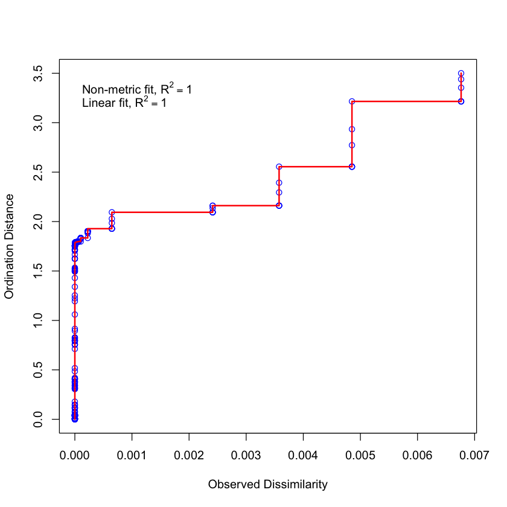

```r
# Assess goodness of ordination fit (stress plot)
stressplot(comm.mntd.mds)
```

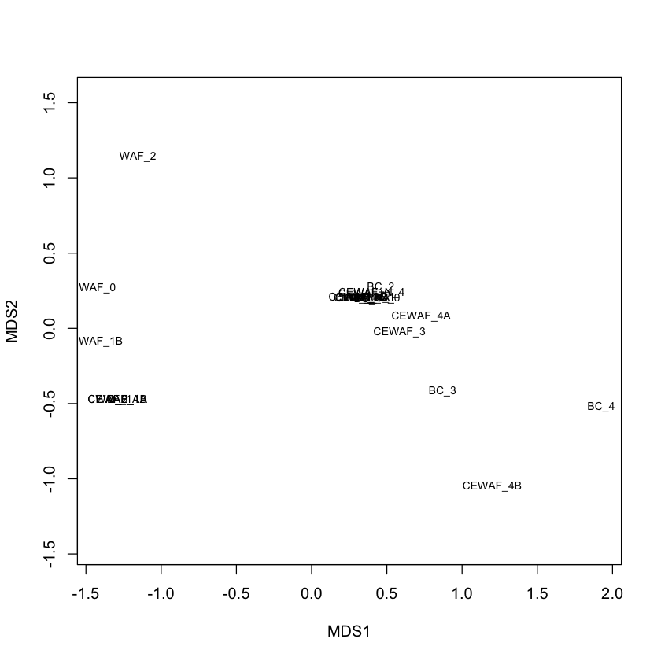

```r
# plot site scores as text
ordiplot(comm.mntd.mds, display = "sites", type = "text")
```

```
species scores not available
```

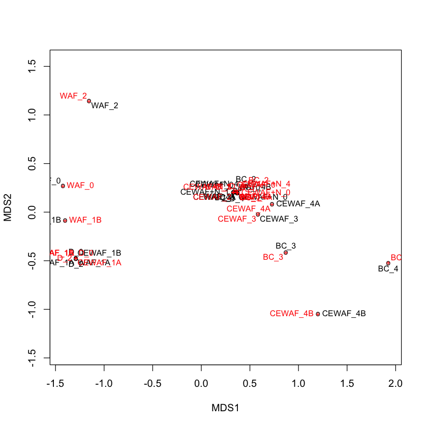

```r
# automated plotting of results - tries to eliminate overlapping labels
ordipointlabel(comm.mntd.mds)
```

# Testing for multivariate differences among groups

We can quantify the relationship between dissimilarity measures and different explanatory variables using the permutational MANOVA (a.k.a. AMOVA) framework in the adonis function in vegan. This method allows ANOVA-like tests of the variance in beta diversity explained by categorical or continuous variables.

```r
# Taxonomic (Bray-Curtis) dissimilarity explained
adonis(comm.bc.dist ~ Dispersant + Oil + Dispersant*Oil + Dispersant*Oil*Nutrients + Time + Dispersant*Time + Oil*Time + Dispersant*Oil*Time + Dispersant*Oil*Nutrients*Time, data = metadata)
```

```
Call:
adonis(formula = comm.bc.dist ~ Dispersant + Oil + Dispersant *      Oil + Dispersant * Oil * Nutrients + Time + Dispersant *      Time + Oil * Time + Dispersant * Oil * Time + Dispersant *      Oil * Nutrients * Time, data = metadata)

Permutation: free
Number of permutations: 999

Terms added sequentially (first to last)

                    Df SumsOfSqs MeanSqs F.Model      R2 Pr(>F)
Dispersant           1    1.0459 1.04588 14.3833 0.26960  0.001 ***
Oil                  1    0.1286 0.12857  1.7681 0.03314  0.151
Nutrients            1    0.0681 0.06810  0.9366 0.01756  0.421
Time                 1    0.6823 0.68226  9.3827 0.17587  0.001 ***
Dispersant:Oil       1    0.1906 0.19056  2.6206 0.04912  0.071 .
Dispersant:Time      1    0.1986 0.19861  2.7314 0.05120  0.054 .
Oil:Time             1    0.1051 0.10505  1.4448 0.02708  0.232
Nutrients:Time       1    0.0668 0.06679  0.9185 0.01722  0.463
Dispersant:Oil:Time  1    0.1574 0.15743  2.1650 0.04058  0.098 .
Residuals           17    1.2362 0.07271         0.31864
Total               26    3.8794                 1.00000
---
Signif. codes:  0 ‘***’ 0.001 ‘**’ 0.01 ‘*’ 0.05 ‘.’ 0.1 ‘ ’ 1
```

```r
# Phylogenetic MNTD dissimilarity explained
adonis(comm.mntd.dist ~ Dispersant + Oil + Dispersant*Oil + Dispersant*Oil*Nutrients + Time + Dispersant*Time + Oil*Time + Nutrients*Time + + Dispersant*Oil*Nutrients*Time, data = metadata)
```

```
Call:
adonis(formula = comm.mntd.dist ~ Dispersant + Oil + Dispersant *      Oil + Dispersant * Oil * Nutrients + Time + Dispersant *      Time + Oil * Time + Nutrients * Time + +Dispersant * Oil *      Nutrients * Time, data = metadata)

Permutation: free
Number of permutations: 999

Terms added sequentially (first to last)

                    Df   SumsOfSqs     MeanSqs F.Model       R2 Pr(>F)
Dispersant           1 -1.2873e-06 -1.2873e-06   19.75 -0.04915  0.056 .
Oil                  1  3.8791e-06  3.8791e-06  -59.51  0.14811  0.993
Nutrients            1 -8.8700e-07 -8.8700e-07   13.61 -0.03387  0.102
Time                 1  2.6194e-05  2.6194e-05 -401.85  1.00013  0.997
Dispersant:Oil       1  1.5973e-05  1.5973e-05 -245.04  0.60986  0.996
Dispersant:Time      1  2.1804e-06  2.1804e-06  -33.45  0.08325  0.976
Oil:Time             1 -4.5807e-06 -4.5807e-06   70.27 -0.17489  0.010 **
Nutrients:Time       1  1.2567e-06  1.2567e-06  -19.28  0.04798  0.967
Dispersant:Oil:Time  1 -1.5429e-05 -1.5429e-05  236.70 -0.58911  0.005 **
Residuals           17 -1.1081e-06 -6.5200e-08         -0.04231
Total               26  2.6191e-05                      1.00000
---
Signif. codes:  0 ‘***’ 0.001 ‘**’ 0.01 ‘*’ 0.05 ‘.’ 0.1 ‘ ’ 1
```

```r
# Phylogenetic MPD dissimilarity explained
adonis(comm.mpd.dist ~ Dispersant + Oil + Dispersant*Oil + Dispersant*Oil*Nutrients + Time + Dispersant*Time + Oil*Time + Nutrients*Time + + Dispersant*Oil*Nutrients*Time, data = metadata)
```

```
Call:
adonis(formula = comm.mpd.dist ~ Dispersant + Oil + Dispersant *      Oil + Dispersant * Oil * Nutrients + Time + Dispersant *      Time + Oil * Time + Nutrients * Time + +Dispersant * Oil *      Nutrients * Time, data = metadata)

Permutation: free
Number of permutations: 999

Terms added sequentially (first to last)

                    Df SumsOfSqs  MeanSqs F.Model      R2 Pr(>F)
Dispersant           1   0.09275 0.092750 2.65097 0.09131  0.001 ***
Oil                  1   0.03847 0.038471 1.09957 0.03787  0.220
Nutrients            1   0.02248 0.022479 0.64250 0.02213  0.929
Time                 1   0.05728 0.057278 1.63711 0.05639  0.015 *
Dispersant:Oil       1   0.04122 0.041217 1.17805 0.04058  0.121
Dispersant:Time      1   0.04988 0.049883 1.42575 0.04911  0.037 *
Oil:Time             1   0.04375 0.043754 1.25059 0.04308  0.108
Nutrients:Time       1   0.02606 0.026058 0.74478 0.02565  0.792
Dispersant:Oil:Time  1   0.04909 0.049092 1.40316 0.04833  0.041 *
Residuals           17   0.59478 0.034987         0.58555
Total               26   1.01576                  1.00000
---
Signif. codes:  0 ‘***’ 0.001 ‘**’ 0.01 ‘*’ 0.05 ‘.’ 0.1 ‘ ’ 1
```